# Lab2 Simulation Methods

Aleksi Patronen

2024-01-23

Assignment 1: Sequential Monte Carlo of a high dimensional distribution

a.) This assignment is based on Example 6.6 (p. 174-175) in Givens and Hoeting (2013). Read through the text carefully and take a look at the associated code. Your first task is to add comments to the code using the information in the text (especially the algorithm description).

```r
########################################################################
### EXAMPLE 6.6 HIGH DIMENSIONAL DISTRIBUTION
#########################################################################
# p = number of dimensions
# n = number of points sampled
# N.eff = effective sample size
# X = sample
# w = importance weights
# rejuvs = number of rejuvenations
# normal.draw = sample from the standard normal envelope.
# ftxt = f_t(x_1:t) in book notation
# ft1xt1= f_t-1(x_1:t-1)
# Note: f_t(x_t|x_1:t-1) = ftxt/ft1xt1
#########################################################################

##INITIAL VALUES
p = 50 # n. of parameters
n = 5000 # n. of obs.

# sample X_t at time t corresponds to column in matrix X
# the i'th row is X_{1:p}^(i)
X = matrix(NA, nrow = n, ncol = p)

w = rep(1, n) / n # initialize weights with uniform 1/n
N.eff = rep(NA, p + 1)
N.eff[1] = n # corresponds to uniform weight distribution
ft1xt1 = w
rejuvs = 0

# store weights
ws = matrix(NA, nrow = n, ncol = p)  # making a weight matrix
# target density function
dens.fun = function(x) {
  temp = function(x) {
    exp(-(abs(sqrt(sum(x ** 2))) ** 3) / 3) # the target density
  }
  # apply the above density function temp to each row (dimension "1") of matrix x
  # i.e. compute value of density function across all samples
  c(apply(x, 1, temp))
}

# 1D variant of above
dens.fun.1 = function(x) {
  exp(-(abs(sqrt(x ** 2)) ** 3) / 3)
}
ncoeff = integrate(dens.fun.1, -999, 999)$value
dens.fun.1.n = function(x) {
  dens.fun.1(x) / ncoeff
}




##MAIN LOOP
set.seed(4567)
# loop over dimensions / time steps
for (i in 1:p) {
  # Generate new sample: n points x_t^(i) from the envelope function N(0,1)
  normal.draw = rnorm(n, mean = 0, sd = 1)

  # Compute values of the target density at x_{1:t}
  if (i == 1) {
    # At first time step, compute a one-dimensional distribution
    ftxt = dens.fun(cbind(normal.draw))
  } else {
    # At later time steps, append new sample to previous to make X_t
    Xtemp = cbind(X[, 1:(i - 1)], normal.draw)
    ftxt = dens.fun(Xtemp)
  }
  # Store new sample to i'th col of matrix X
  X[, i] = normal.draw

  # See comment (*)
  #calculate the weight adjustment factor
  w = w * ftxt / (ft1xt1 * dnorm(normal.draw))

  # Store values at current time step to ft1xt1
  ft1xt1 = ftxt

  # Normalize and store weights
  w = w / sum(w)
  ws[, i] = w

  # Compute effective sample size
  N.eff[i + 1] = 1 / sum(w ** 2)

  # If ESS is less than predetermined threshold - here 1/5 of sample size,
  # perform resampling/rejuvenation
  if (N.eff[i + 1] < N.eff[1] / 5) {
    rejuvs = rejuvs + 1

    # Sample indices j from (1,...,n) with replacement, with probabilities w_j
    idx = sample(1:n, n, replace = T, prob = w)

    # Keep rows corresponding to indices idx from sample matrix X
    X = X[idx,]

    # Re-compute density function
    ft1xt1 = dens.fun(X[, 1:i])

    # Reset sample weights
    w = rep(1, n) / n
  }
}
```

b.) Run the code until the last section that starts with #NOW TRY TO… Provide a plot of the effective sample size over iterations and explain the results.

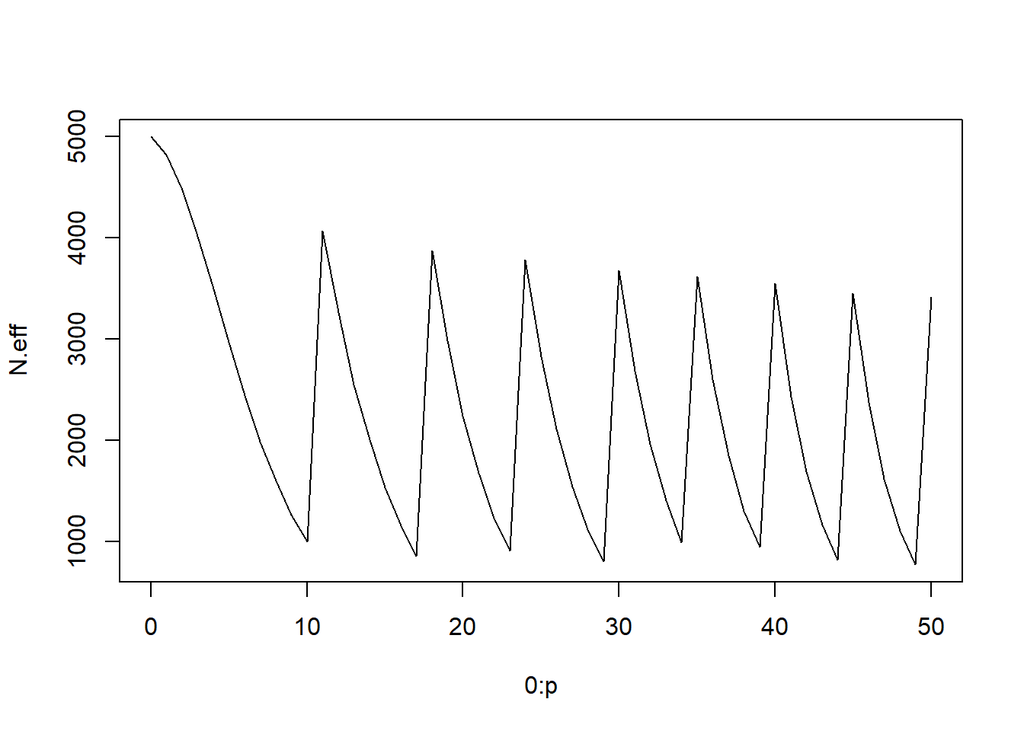

```r
plot(0:p, N.eff, type = 'l') #plotting
```

```r
#5000/N.eff[-1] #
```

This plot shows the rejuvenation events in the algorithm. On y axis is the effective sample size and x axis is the iterations.when ever the ess decent to low, weights are initialized to their original value to avoid degeneracy of the sampling.

c.) Calculate means and 95% confidence intervals of the sampled values X for each of p (over the iterations) and produce a plot of these results (that includes both means and confidence intervals). In addition, produce a density of all X values (merged over p) and discuss how it relates to the information given in the text.

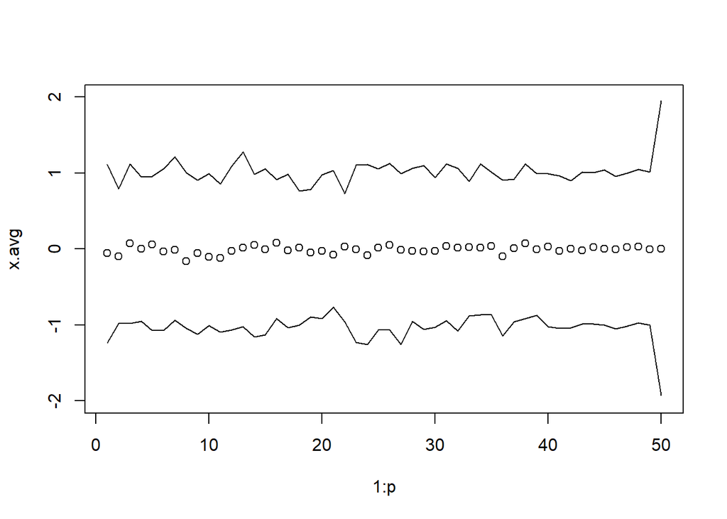

```r
x.avg <- apply(X, 2, mean)
x.ci <- apply(X, 2, quantile, c(0.025, 0.975))
plot(1:p, x.avg, ylim = c(-2, 2))
lines(1:p, x.ci[1, ])
lines(1:p, x.ci[2, ])
```

This shoes the mean of the target distribution (points) and the 95%CI in lines during the run of the algorithm.

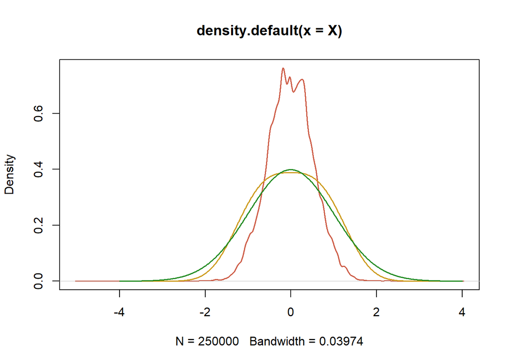

```r
x.dens <- density(X)
plot(x.dens, col = 'coral3', lwd = 1.5)
v <- seq(-4, 4, 0.01)
lines(v, dens.fun.1.n(v), col = 'goldenrod3', lwd = 1.5)
lines(v, dnorm(v), col = 'forestgreen', lwd = 1.5)
```

This shows the target dist.(gold), norm in green, and the algorithm given distribution in red. It clearly shows how much smaller the distribution variance is.

d.) Produce density plots of the weights over iterations. Discuss the results.

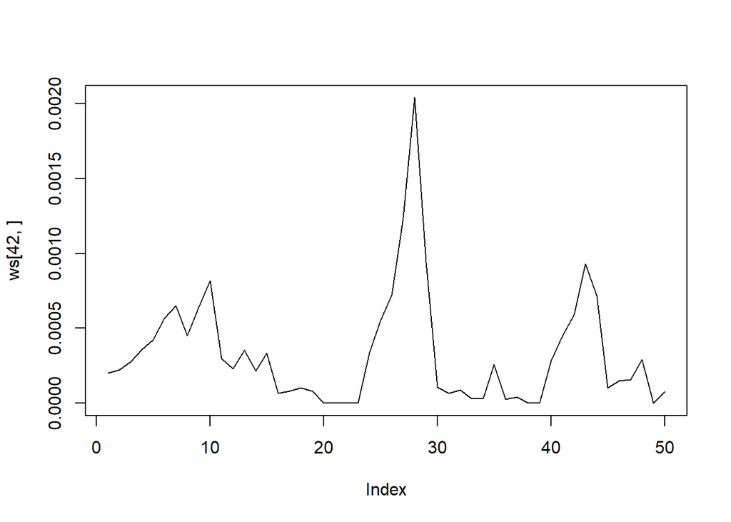

```r
plot(ws[42, ], type = 'l')
```

this graph shows the weights. It would seem that weights in the middle of the pack are a lot larger than others.

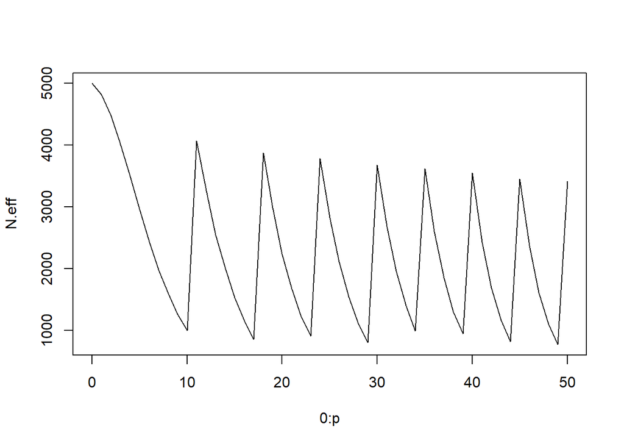

```r
plot(x = 0:p, y = N.eff, type = "l")
```

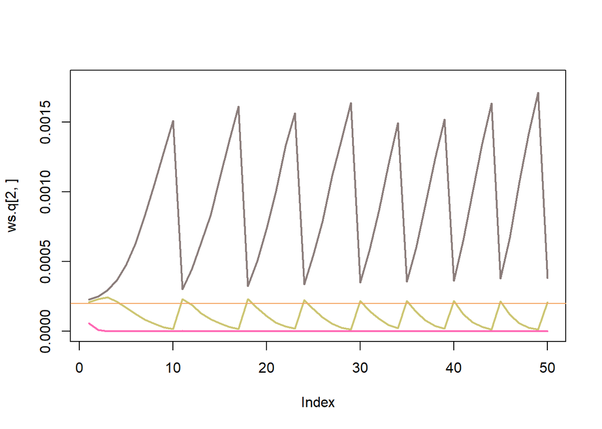

```r
ws.q <- apply(ws, 2, quantile, c(0.025, 0.5, 0.975))
plot(ws.q[2, ], type = 'l', ylim = c(0, 0.0018), col = 'khaki3', lwd = 2)
lines(ws.q[1, ], col = 'hotpink', lwd = 2)
lines(ws.q[3, ], col = 'mistyrose4', lwd = 2)
abline(h = 0.0002, col = 'sandybrown')
```

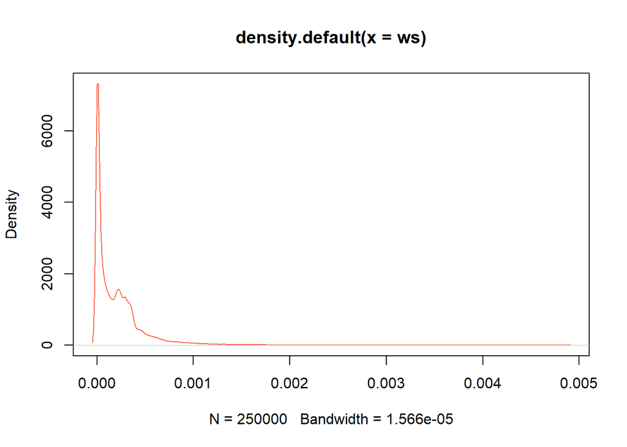

```r
plot(density(ws), col = 'tomato')
```

e.) Run the last part of the code and discuss if the results correspond well with the information given in the text.

```r
#NOW TRY TO EXPEND ALL EFFORT ON ONE SIR OF 5000 PTS
set.seed(11)
x = matrix(rnorm(50 * 5000), 5000, 50)
g = dnorm(x)
f = dens.fun(x)

# Importance weights: Denominator is N_p(0,I_p)
impwt = f / apply(g, 1, prod)
impwt = impwt / sum(impwt)
#ESS
1 / sum(impwt ** 2)  #Answer varies with random number seed
```

```
## [1] 1.704374
```